# Adam Zeilinger ZIB model (v.2)

Daniel Turek

## Updates (v.2)

- Using new data set with N = 958 observations (lists >= 4 species)
- Removed quadratic year^2 effect, and added year:month and year:month^2 interactions to occpancy process
- Transformed new siteID (raster cell numbers) into sequential indexing of random effects
- Changed the prior for sigma_alpha form uniform(0, 500) to uniform(0, 1000), to capture more of the long right-tail of the posterior.

## Introduction

We’ll look at two different ways of parametrizing your model. The first uses latent states, the traditional form for occupancy models, and is the only to fit these models in most software. The second parametrization will be NIMBLE-only, and we’ll see is much faster.

I did some pre-processing of your data, to remove the huge numble of NA’s from the raw observation matrix. Instead of large 2-dimensional arrays with only roughly 900 actual observations, the data is now in “flat” structures: 1-dimensional vectors containing *only* the 900 actual obsevations, with a new site-membership indicator variable “siteID” for correctly assigning the site random effects. To see the data processing that takes place, take a look at create_data.R.

```r
## load libraries
require(nimble)
require(rjags)
require(coda)

## load the processed data
load('../data/zib_data_v3.RData')

## some other function definitions for custom samplers, ploting, etc.
source('definitions.R')

## this has to do with how the page is being made
fromR <- TRUE
```

## Latent state model

The latent state version of the model includes the latent variables `z`, indicating true presence / absense. Including these introduces about 900 additional unknown variables into the model which must be sampled, which slows down the MCMC a lot.

In the second formulation of the model, we’ll use a custom distribution in NIMBLE to remove these latent states. But to use JAGS (for the first comparison), we can’t use custom distributions, and therefore we use the latent state model representation.

```r
## latent state model code
code <- nimbleCode({
    mu_alpha ~ dnorm(0, 0.001)
    sigma_alpha ~ dunif(0, 1000)
    tau_alpha <- 1 / (sigma_alpha * sigma_alpha)
    for(j in 1:nsite) {
        alpha[j] ~ dnorm(mu_alpha, tau_alpha)  ## site random effect
    }
    for(i in 1:11) {
        beta[i] ~ dnorm(0, 0.001)
    }
    ## notice the single index i, using the new "flat" data structures
    ## also the siteID group membership, used to assign the correct random effect
    for(i in 1:N) {
        logit(p_occ[i]) <- alpha[siteID[i]] + beta[4]*aet[i] + beta[5]*tmn[i] + beta[6]*tmx[i] + beta[7]*year[i] + beta[8]*month[i] + beta[9]*month2[i] + beta[10]*year_month[i] + beta[11]*year_month2[i]
        logit(p_obs[i]) <- beta[1] + beta[2]*list_length[i] + beta[3]*year_list_length[i]
        z[i] ~ dbern(p_occ[i])
        mu_y[i] <- z[i] * p_obs[i]
        y[i] ~ dbern(mu_y[i])
    }
})

constants <- list(N=N, nsite=nsite, aet=aet, tmn=tmn, tmx=tmx, year=year, month=month, month2=month2, year_month=year_month, year_month2=year_month2, list_length=list_length, year_list_length=year_list_length, siteID=siteID)

data <- list(y=y)

inits <- list(mu_alpha=0, sigma_alpha=1, alpha=rep(0,nsite), beta=rep(0,11), z=rep(1,N))

## LS indicates model information for the latent state version
modelInfo_LS <- list(code=code, constants=constants, data=data, inits=inits, name='LS')
```

We can use both NIMBLE and JAGS to fit the latent state model.

We’ll use 22,000 iterations, after 2,000 burnin will leave 20,000 samples.

```r
niter <- 22000

set.seed(0)

comp_LS <- compareMCMCs(modelInfo_LS,
                        niter = niter,
                        summary = TRUE,
                        MCMCs = c('jags','nimble'))

save(comp_LS, file = '../cached/comp_LS.RData')
```

Take a look at how quickly that ran, and the resulting effective sample size (ESS).

```r
## runtime (in minutes) of each algorithm
comp_LS$LS$timing / 60
```

```
##           jags         nimble nimble_compile
##      7.8644000      0.6072167      0.4633667
```

JAGS takes about 8 minutes, NIMBLE takes about 30 seconds, to produce 20,000 samples.

ESS takes into account the autocorrelation in the posterior chains, and is a measure of the actual number of *independent* posterior samples. At this point, it’s worth you taking a few minutes to read about this metric of MCMC performance. There’s a good description of it [available here](https://nature.berkeley.edu/~pdevalpine/MCMC_comparisons/nimble_MCMC_comparisons.html).

Here is the *minimum efficiency* across all sampled parameters, which is the number of effective (independent) samples produced per second of runtime.

```r
comp_LS$LS$efficiency$min
```

```
##        jags      nimble
## 0.005726672 0.087183805
```

JAGS has minimum efficiency about 0.005, meaning it produces about 1 sample every 3 minutes (for the slowest mixing parameter). NIMBLE has minimum efficiency of 0.087, meaning it produces about 1 sample every 11 seconds (again, for the slowest mixing parameter).

## Custom distribution representation

Now we’ll write the model in a different way. I’ve written a custom distribution for use in the model specification, called `dOccupancy`. You can see the definition of this in definitions.R. As parameters it takes the occupancy probability `p_occ` and the observation probability `p_obs`, and it returns the marginalized probability density of the observation.

You can see the new model specification below, without the latent `z` variables, and using the custom `dOccupancy` distribution for the observations `y`. This model can only be used with NIMBLE.

```r
## latent state model code
code <- nimbleCode({
    mu_alpha ~ dnorm(0, 0.001)
    sigma_alpha ~ dunif(0, 1000)
    for(j in 1:nsite) {
        alpha[j] ~ dnorm(mu_alpha, sd = sigma_alpha)  ## site random effect
    }
    for(i in 1:11) {
        beta[i] ~ dnorm(0, 0.001)
    }
    for(i in 1:N) {
        logit(p_occ[i]) <- alpha[siteID[i]] + beta[4]*aet[i] + beta[5]*tmn[i] + beta[6]*tmx[i] + beta[7]*year[i] + beta[8]*month[i] + beta[9]*month2[i] + beta[10]*year_month[i] + beta[11]*year_month2[i]
        logit(p_obs[i]) <- beta[1] + beta[2]*list_length[i] + beta[3]*year_list_length[i]
        y[i] ~ dOccupancy(p_occ[i], p_obs[i])
    }
})

constants <- list(N=N, nsite=nsite, aet=aet, tmn=tmn, tmx=tmx, year=year, month=month, month2=month2, year_month=year_month, year_month2=year_month2, list_length=list_length, year_list_length=year_list_length, siteID=siteID)

data <- list(y=y)

## Note: no longer have initial values for "z", since it's been removed from the model.
inits <- list(mu_alpha=0, sigma_alpha=1, alpha=rep(0,nsite), beta=rep(0,11))

modelInfo_dOccupancy <- list(code=code, constants=constants, data=data, inits=inits, name='dOccupancy')
```

Now we’ll do some runs with this model. Since it will run much faster, we’ll do 502,000 iterations. I’m only choosing that number such that after the burnin of 2,000 iterations, we’ll retain 500,000 posterior samples.

We’ll consider a large number of different MCMC algorithms. This serves two purposes:

- Finding the most efficient algorithm
- Comparing posteriors to help us assess convergence

I did a fair bit of experimenting (not shown here) to arrive at this list of well-performing candidate MCMCs, but it’s still intersting to look at the performance of all of them. Just to briefly describe each MCMC algorithm:

- nimble: NIMBLE’s default MCMC.
- block: Putting block samplers on the coefficients in each linear predictor term, which are very likely to be correlated in the posterior.
- log_shft: We will see that `sigma_alpha` is the slowest mixing parameter, so we’ll try to speed that up (since the mixing of this parameter will therefore limit our inferential power for the rest of the model). This MCMC samples `sigma_alpha` on a log scale, and also helps it mix by shifting the `alpha` random effects proportionally for every change in `sigma_alpha`.
- log_shft_blk: Combination of the above two ideas. Using block sampling for coefficients, and also the log-shift sampling for `sigma_alpha`.
- log_shft2_blk: Same as above, but also does shift sampling for `mu_alpha`, that is it shifts the `alpha` random effect values by the same amount for every change in `mu_alpha`, which will help the mixing of `mu_alpha`.

If you take a minute to look at the `MCMCdefs` argument list below, you’ll get some insight about how MCMC algorithms can be customized in NIMBLE.

```r
niter <- 502000

set.seed(0)

comp_dOcc <- compareMCMCs(modelInfo_dOccupancy,
                          MCMCs = c('nimble', 'block', 'log_shft', 'log_shft_blk', 'log_shft2_blk'),
                          niter = niter,
                          summary = FALSE,
                          MCMCdefs = list(
                              block = quote({
                                  spec <- configureMCMC(Rmodel)
                                  spec$removeSamplers('beta[1:10]')
                                  spec$addSampler('beta[1:3]', 'RW_block')
                                  spec$addSampler('beta[4:11]', 'RW_block')
                                  spec }),
                              log_shft = quote({
                                  spec <- configureMCMC(Rmodel)
                                  spec$removeSamplers('sigma_alpha')
                                  spec$addSampler('sigma_alpha', 'RW_log_shift', list(shiftNodes='alpha'))
                                  spec }),
                              log_shft_blk = quote({
                                  spec <- configureMCMC(Rmodel)
                                  spec$removeSamplers('beta[1:10]')
                                  spec$addSampler('beta[1:3]', 'RW_block')
                                  spec$addSampler('beta[4:11]', 'RW_block')
                                  spec$removeSamplers('sigma_alpha')
                                  spec$addSampler('sigma_alpha', 'RW_log_shift', list(shiftNodes='alpha'))
                                  spec }),
                              log_shft2_blk = quote({
                                  spec <- configureMCMC(Rmodel)
                                  spec$removeSamplers('beta[1:10]')
                                  spec$addSampler('beta[1:3]', 'RW_block')
                                  spec$addSampler('beta[4:11]', 'RW_block')
                                  spec$removeSamplers('sigma_alpha')
                                  spec$addSampler('sigma_alpha', 'RW_log_shift', list(shiftNodes='alpha'))
                                  spec$removeSamplers('mu_alpha')
                                  spec$addSampler('mu_alpha', 'RW_shift', list(shiftNodes='alpha', skipDependencies=FALSE))
                                  spec })
                          ))

save(comp_dOcc, file = '../cached/comp_dOcc.RData')
```

Here’s a really nice feature of NIMBLE’s MCMC comparisons: the MCMC comparisons pages. This next command will generate nice visual summaries of the performance of all the MCMC algorithms we just ran.

```r
make_MCMC_comparison_pages(comp_dOcc, dir = '../html')
```

It’s worth spending at least a few minutes looking over [these comparison pages](http://danielturek.github.io/zib_glmm/html/dOccupancy.html). At this point we can start making some conclusions.

Looking at the Posterior Summaries section at the bottom of the [comparisons page](http://danielturek.github.io/zib_glmm/html/dOccupancy.html), we see that all MCMC algorithms appear to have converged nicely to the same posterior distribution. The only one with any noticeable differences is the posterior for `sigma_alpha`, but the differences are minor. Also, for the purposes of your biological anlysis, the standard deviation of the site random effects is probably not the most critical model parameter. We’ll check convergence otherwise, but this gives us good confidence in the results.

We’ll accept this MCMC algorithm, log_shft_blk, as the “best” algorithm hereafter, although most all of these algorithms would be just fine to use.

Before we go ahead an run it longer, let’s examine a few more things.

See how long it took to actually run these, for 500,000 samples.

```r
comp_dOcc$dOccupancy$timing / 60
```

```
##         nimble          block       log_shft   log_shft_blk  log_shft2_blk
##      8.8871000      3.6861333      9.6912333      4.4794500      5.0643833
## nimble_compile
##      0.7157167
```

log_shft_blk algorithm took about 4.5 minutes, not too bad at all.

What was the actual Effective Sample Size (ESS) it produced for all parameters? Let’s make sure it’s somewhat reasonable.

```r
comp_dOcc$dOccupancy$summary['log_shft_blk', 'ess',]
```

```
##    mu_alpha sigma_alpha     beta[1]     beta[2]     beta[3]     beta[4]
##    9173.314    1871.769   14504.144   33745.911   27956.884    3837.241
##     beta[5]     beta[6]     beta[7]     beta[8]     beta[9]    beta[10]
##    3817.024    3702.984    3205.676    4239.242    2836.220    3051.384
##    beta[11]
##    6439.226
```

The smallest ESS is for `sigma_alpha` (as we knew), with about 1,900 independent posterior samples. The others are all more. This is ok, but we’ll run the algorithm for longer the final analysis.

Let’s also just take a look at the mixing for `sigma_alpha`, to make sure it looks ok.

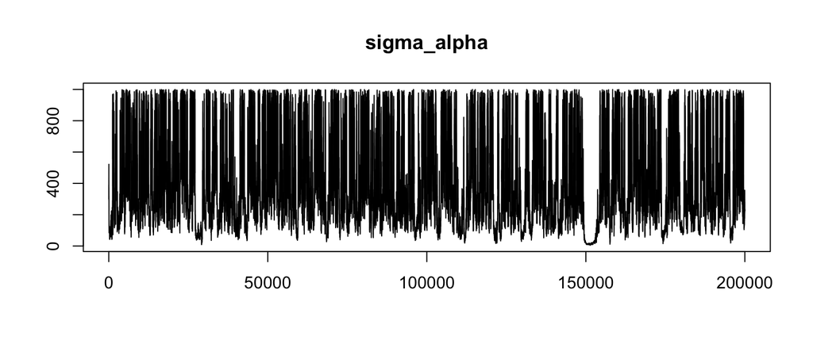

```r
if(fromR) dev.new(width=8, height=3.5)
tsplot(comp_dOcc$dOccupancy$samples['log_shft_blk', 'sigma_alpha', 300000:500000], main='sigma_alpha', xlab='', ylab='')
```

The mixing is good. Not the best we can imagine, and it’s definitely upper-truncated at 1000, but this is fine overall.

## Final MCMC runs

Finally, we’ll go ahead and run two chains of this MCMC, double-check convergence, and look at some posterior statistics.

The code below uses NIMBLE’s core MCMC functionality. We’ll create and compile this one MCMC algorithm, and run two chains each of 1,000,000 iterations. This will give us reasonably good inferentialy power for all parameters.

```r
## create the R model
Rmodel <- nimbleModel(modelInfo_dOccupancy$code,
                      modelInfo_dOccupancy$constants,
                      modelInfo_dOccupancy$data,
                      modelInfo_dOccupancy$inits)

## compile the model to C++
Cmodel <- compileNimble(Rmodel)

## create a default MCMC specification
spec <- configureMCMC(Rmodel)

## configure this specification the same as log_shft_blk from above
spec$removeSamplers('beta[1:10]')
spec$addSampler('beta[1:3]', 'RW_block')
spec$addSampler('beta[4:11]', 'RW_block')
spec$removeSamplers('sigma_alpha')
spec$addSampler('sigma_alpha', 'RW_log_shift', list(shiftNodes='alpha'))

## build the R MCMC algorithm, and compile it to C++
Rmcmc <- buildMCMC(spec)
Cmcmc <- compileNimble(Rmcmc, project = Rmodel)
```

Now we’ll run two chains of this MCMC algorithm, each with one million MCMC iterations.

We’ll also manually remove the first 100,000 samples as burnin.

```r
niter <- 1000000

## run the first chain and collect samples
set.seed(1)
Cmcmc$run(niter)
samples1 <- as.matrix(Cmcmc$mvSamples)[100001:niter, ]

## run the second chain and collect samples
set.seed(2)
Cmcmc$run(niter)
samples2 <- as.matrix(Cmcmc$mvSamples)[100001:niter, ]

## create mcmc and mcmc.list objects for plotting and convergence diagnostics
mcmc1 <- coda::as.mcmc(samples1)
mcmc2 <- coda::as.mcmc(samples2)
mcmcs <- coda::mcmc.list(mcmc1, mcmc2)

save(samples1, samples2, mcmcs, file = '../cached/final_MCMC.RData')
```

## Assessing convergence

Now we assess convergence using these two MCMC chains.

We’ll use the mainstream Gelman & Rubin convergence diagnostic from the `coda` package. We want to see all values near to 1.

```r
coda::gelman.diag(mcmcs, autoburnin = FALSE)
```

```
## Potential scale reduction factors:
##
##             Point est. Upper C.I.
## beta[1]              1          1
## beta[2]              1          1
## beta[3]              1          1
## beta[4]              1          1
## beta[5]              1          1
## beta[6]              1          1
## beta[7]              1          1
## beta[8]              1          1
## beta[9]              1          1
## beta[10]             1          1
## beta[11]             1          1
## mu_alpha             1          1
## sigma_alpha          1          1
##
## Multivariate psrf
##
## 1
```

Convergence looks excellent, on all counts.

Let’s also just take a quick look at the Effective Sample Size (ESS) that we’ve actually collected for each parameter. We’ll just look at the first chain.

```r
apply(samples1, 2, coda::effectiveSize)
```

```
##     beta[1]     beta[2]     beta[3]     beta[4]     beta[5]     beta[6]
##   24219.376   57414.527   48177.197    6456.521    6566.255    6813.343
##     beta[7]     beta[8]     beta[9]    beta[10]    beta[11]    mu_alpha
##    5849.225    7436.149    4555.909    5423.368    9987.617   15227.869
## sigma_alpha
##    3407.238
```

These vary a lot, but we have over 3,400 independent samples for `sigma_alpha`, and more for all the other parameters. Perhaps we could desire more, but this will be enough for our inferences. Of course if you want more samples, you can use this code to generate more.

## Posterior Inferences

Finally! We have lots of samples that we’re happy with. Now we can now make posterior inferences. For extra assurance, we’ll make the inferences from both chain1 and chain2, and expect to see (essentially) the same results.

Let me know if you want any help on how to interpet or use any of these numbers. As far as interpreting the actual `beta[i]` parameters, you’ll have to just look back at the model specifications above to see what each `beta[i]` represents, but that’s easy enough.

### Posterior Mean

```r
cbind(apply(samples1, 2, mean),
      apply(samples2, 2, mean))
```

```
##                    [,1]        [,2]
## beta[1]      -2.5260141  -2.5262602
## beta[2]       0.3252532   0.3257614
## beta[3]       0.3502224   0.3492628
## beta[4]     -18.6992482 -19.4907584
## beta[5]     -12.9820305 -12.4044669
## beta[6]     -10.6400112 -10.7344205
## beta[7]      39.1432505  39.0224169
## beta[8]       6.7608106   6.2814623
## beta[9]       7.2474760   7.4153863
## beta[10]     -3.8200356  -3.8888418
## beta[11]     22.8458447  22.7891061
## mu_alpha     -9.9773927 -10.0218086
## sigma_alpha 385.0643506 382.3887477
```

### Posterior Median

```r
cbind(apply(samples1, 2, median),
      apply(samples2, 2, median))
```

```
##                    [,1]        [,2]
## beta[1]      -2.5211059  -2.5224654
## beta[2]       0.3265380   0.3266207
## beta[3]       0.3464049   0.3460529
## beta[4]     -18.6388322 -20.0663195
## beta[5]     -12.9465370 -12.2381188
## beta[6]     -11.2745331 -11.6054022
## beta[7]      39.8831174  39.4112948
## beta[8]       6.0773086   5.6104935
## beta[9]       6.5255718   6.8424729
## beta[10]     -5.0394267  -4.8805235
## beta[11]     21.9890668  21.7996017
## mu_alpha    -10.5951618 -10.8742023
## sigma_alpha 318.1632276 317.7585769
```

We see the posterior distributions are only mildly skewed, the one exception being `sigma_alpha`.

### Credible Intervals

```r
cbind(apply(samples1, 2, function(x) quantile(x, 0.025)),
      apply(samples1, 2, function(x) quantile(x, 0.975)))
```

```
##                      [,1]        [,2]
## beta[1]      -2.975900107  -2.1038216
## beta[2]       0.001502609   0.6415328
## beta[3]       0.000361155   0.7190607
## beta[4]     -75.854649742  38.2438102
## beta[5]     -65.970378852  40.6971088
## beta[6]     -64.285233536  46.0320320
## beta[7]     -15.437966350  90.4238936
## beta[8]     -41.861756799  58.8686918
## beta[9]     -43.104443931  61.3540441
## beta[10]    -53.265040948  51.3716912
## beta[11]    -21.879246748  72.4923686
## mu_alpha    -68.012830285  51.9179176
## sigma_alpha  43.575440459 947.6915373
```

### Standard Error

```r
cbind(apply(samples1, 2, sd),
      apply(samples2, 2, sd)) / dim(samples1)[1]
```

```
##                     [,1]         [,2]
## beta[1]     2.464199e-07 2.454498e-07
## beta[2]     1.812290e-07 1.816628e-07
## beta[3]     2.026663e-07 2.024754e-07
## beta[4]     3.229490e-05 3.187157e-05
## beta[5]     2.981792e-05 2.980098e-05
## beta[6]     3.070105e-05 3.044373e-05
## beta[7]     2.997570e-05 2.989825e-05
## beta[8]     2.830653e-05 2.848648e-05
## beta[9]     2.913494e-05 2.901240e-05
## beta[10]    2.939266e-05 2.949326e-05
## beta[11]    2.680691e-05 2.639713e-05
## mu_alpha    3.417885e-05 3.414433e-05
## sigma_alpha 2.922768e-04 2.922754e-04
```

Pleasingly, very small standard errors for each parameter. That’s a direct result of having been able to collect so many samples from a highly-efficient MCMC algorithm.

### Posterior Density Plots

We’ll only plot posterior densities from the first chain.

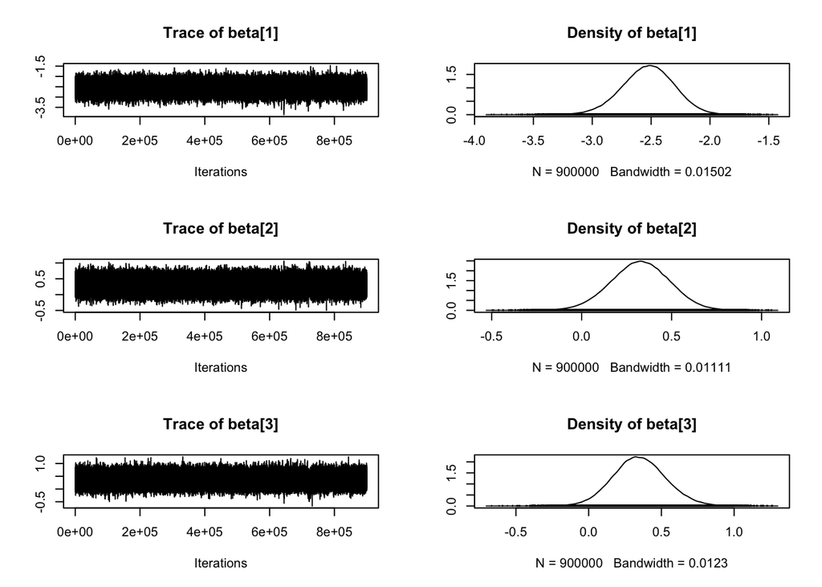

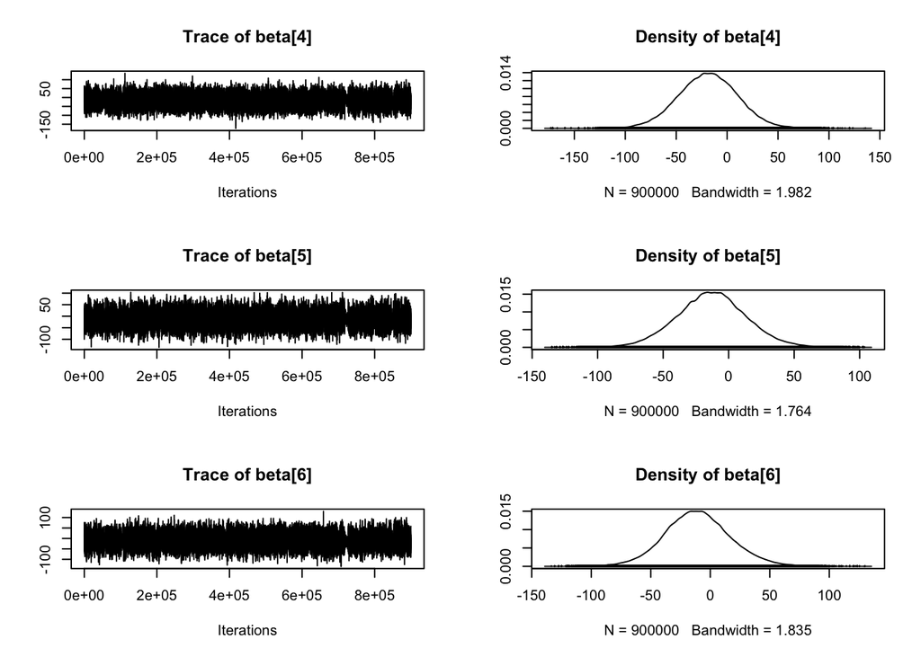

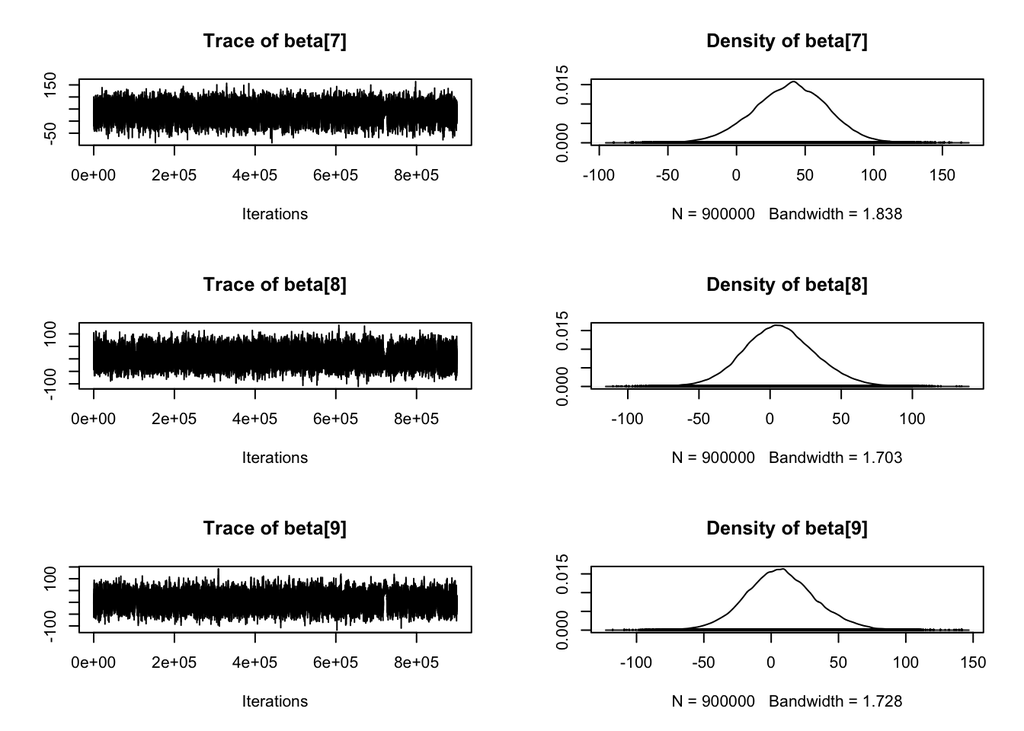

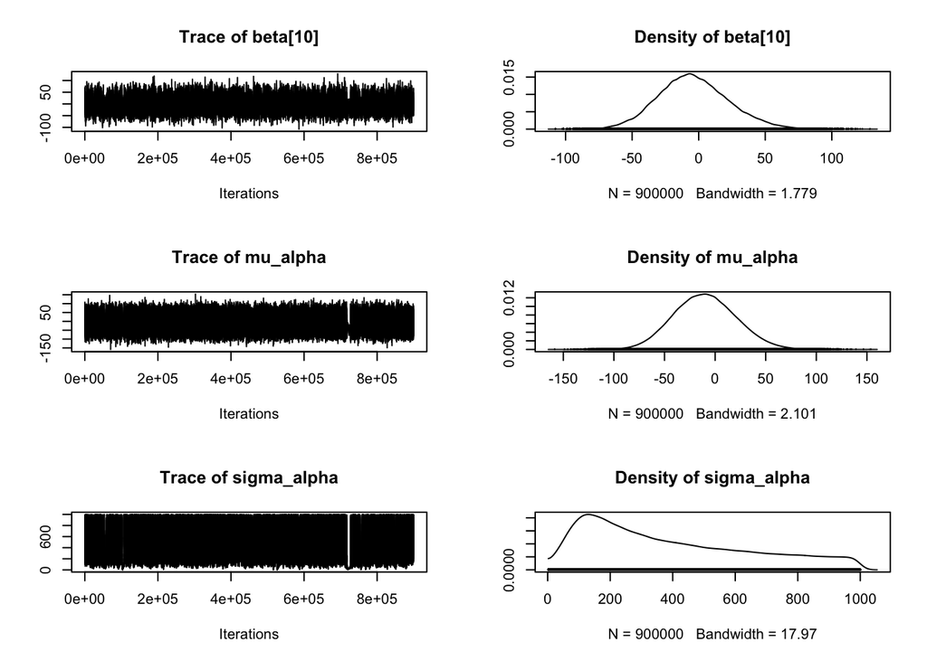

```r
plot(mcmcs[[1]], ask = FALSE)
```

## Wrap Up

I suspect there might still be some changes or modifications to your model or dataset. If that’s the case, it’s ok. Just keep in touch.

Also, I’ll be happy to contribute a short bit on fitting the model for any publications that come out of this work.

Cheers! - Daniel